# Homework 5: Regularization, Perceptron, and Deep Neural Networks

#### Edwin Ramirez, Kandace Mok, Darshil Desai

```python
import pandas as pd
from pandas import DataFrame
import numpy as np
import matplotlib.pyplot as plt
from numpy.linalg import inv
import seaborn as sns
import random
import time
import progressbar
from IPython.display import display, Math, Image
```

## Problem 1

Consider a learning scenario where the goal is to learn the target function $f(x) = sin(πx)$ for $−1 \leq x \leq +1$ from two points in the training sets. The two training points in $R^{2}$ have a uniform distribution between -1 and +1. You will create two models in linear hypothesis set $y = mx + b$: 1) unregularized, 2) weight-decay regularized (use L2 regularization with λ = 0.1).

1. (5 points) Generate 10,000 hypotheses for each version. Report the average hypothesis $\bar{g}(x)$ in each case.
2. (5 points) Find and report bias2 for each model.
3. (5 points) Find and report variance for each model
4. (5 Points) For each case, plot $\bar{g}(x)$ $\pm \sqrt{var}$ along with $\bar{g}(x)$ and target function $f(x) = sin(πx)$. Which model will you choose? Why? **Round your answers to 3 decimal places.**

### 1.1) Report the Average Hypothesis $\bar{g}(x)$ For Each Model

```python
#random.seed(19999)
X = list(range(20000))
x_vals = [round(random.uniform(-1,1), 5) for val  in X]


#Generate point coordinates (x, f(x))
points = np.array([np.array([1, x, np.sin(np.pi*x)]) for x in x_vals])

#Separate points
point1 = points[0:10000]
point2 = points[10000:]
```

First we randomly generate 20,000 points in order to create 10,000 hypotheses. Each hypothesis signifies a linear model that generates a line between two points. All the starting points are stored in the array `point1`, and the ending points are stored in the array `point2`. Both `point1` and `point2` contain 10,000 rows and 3 columns, where each row signifies an array containing an individual hypothesis. Index 0 for all hypotheses contains the bias term , index 1 contains the randomly generated x values, and finally index 2 signifies the output of x in the target function $f(x) = sin(\pi x)$.

Every array signifies a linear model in the form:

$$w_{0} + w_{1}x = y$$

where $w_{0}$ and $w_{1}$ signify the the unkown weights (y-intercept and slope) of each hypothesis. Therefore we will be solving the slope and y-intercept values for 10,000 hypotheses in the following matrix form:

$$ Xw = y \\ { \begin{bmatrix} x_{10} & x_{11}\\ x_{20} & x_{21} \end{bmatrix} \begin{bmatrix} w_{0} \\ w_{1} \end{bmatrix} = y } $$

Since the goal is to analyze the linear models when they are regularized and unregularized, the next task is to compute the weights for all 10,000 regularized linear hypotheses and 10,000 unregularized linear hypotheses.

#### Average Unregularized Linear Hypothesis

In order to obtain the weights for each hypothesis we will be using the following formula: $$w = (X^{T}X)^{-1}X^{T}y$$

```python
def unregularized(point_1, point_2):
    '''
    Returns the unregularized weights of a line between 2 points

    --------------------------------------------------------------------------
    Parameters:

    point_1: an array containing the observation features
    point_2: an array containing the observation features
    --------------------------------------------------------------------------


    Returns: An array w with the weights that signify the y-intercept and slope
             y-intercept at index 0 and slope at index 1
    '''
    x_ = np.array([point_1[0:2], point_2[0:2]])
    y_ = np.array([point_1[2], point_2[2]])

    w =  np.dot(np.dot(np.linalg.inv(np.dot(x_.T, x_)), x_.T), y_)
    return w
```

Through the use of the function above, we obtain the weights for all 10,000 unregularized hypotheses. In order to compute the **average unregularized linear hypothesis**, we simply compute the mean for all 10,000 slopes and y-intercepts computed.

```python
#Slopes and intercepts for all unregularized hypotheses
unreg_w = np.array([unregularized(point1[i], point2[i]) for i in range(10000)])

#Compute the slope and y intercept of the average unregularized linear hypothesis
avg_b = np.mean(unreg_w.T[0])
avg_m = np.mean(unreg_w.T[1])

print(" Average Unregularized Linear Hypothesis: y = " + str(round(avg_m,3)) +'x + ' + str(round(avg_b,3)))
```

```
 Average Unregularized Linear Hypothesis: y = 0.78x + 0.003
```

#### Average Regularized Linear Hypothesis

To compute the weights of our regularized models, we first introduce the regularization term $\lambda$, where we set the constraint solution of are weights to the following:

$$w = (X^{T}X + \lambda I)^{-1}X^{T}y$$

where $\lambda = 0.1$ and will determine how much regularization is applied to the models.

```python
def regularize(point_1, point_2):
    '''
    Returns the regularized weights of a line between 2 points

    -------------------------------------------------------------------------
    Parameters:

    point_1: an array containing the observation features
    point_2: an array containing the observation features
    -------------------------------------------------------------------------

    Returns: An array w with the weights that signify the y-intercept and slope
             y-intercept at index 0 and slope at index 1
    '''
    X = np.array([point_1[0:2], point_2[0:2]])
    y = np.array([point_1[2], point_2[2]])
    lambda_I = np.identity(2)*0.1
    #w = np.dot(np.dot(np.linalg.inv(np.add(np.dot(x_.T, x_), lambda_I)), x_.T), y_)
    w = np.dot(inv(np.dot(X.T, X) + 0.1*np.identity(2)), np.dot(X.T, y))

    return w
```

Just as with the unregularized models, the function above will collect all weights for all 10,000 hypotheses. In order to compute the average regularized linear model, we take the mean of all slopes and y-intercepts.

```python
#Slopes and intercepts for all regularized hypotheses
reg_w = np.array([regularize(point1[i], point2[i]) for i in range(10000)])

#Compute the slope and y intercept of the average regularized linear hypothesis
avg_b_r = np.mean(reg_w.T[0])
avg_m_r = np.mean(reg_w.T[1])

print(" Average Regularized Linear Hypothesis: y = " + str(round(avg_m_r,3)) +'x + ' + str(round(avg_b_r,3)))
```

```
 Average Regularized Linear Hypothesis: y = 0.634x + 0.005
```

### 1.2) Compute the $Bias^{2}$ of Each Model

In order to compute the $bias^{2}$ for all hypotheses, $g(x) = b$, we simply compute the differences between the target function values found in `points` and the average hypothesis $\bar{g}$ and square them.

$$bias(x) = \bar{g}(x) - f(x) \\ f(x) = sin(\pi x) \\ \bar{g}(x) = mx + b$$

```python
#Get hypothesis values for all 20000 observations
g_bar_unr = np.array([points[i][1]*avg_m + avg_b for i in range(20000)])
g_bar_r = np.array([points[i][1]*avg_m_r + avg_b_r for i in range(20000)])


y = points.T[2]

#Bias square values for unregularized model
bias_sq_unr = np.power(g_bar_unr - y, 2)

#Bias square values of regularized model
bias_sq_r = np.power(g_bar_r - y, 2)

#Expected bias for each model
exp_bias_sq_unr = bias_sq_unr.mean()
exp_bias_sq_r = bias_sq_r.mean()
```

```python
print("Unregularized Bias Squared: " + str(round(exp_bias_sq_unr,3)))
print("Regularized Bias Squared: " + str(round(exp_bias_sq_r,3)))
```

```
Unregularized Bias Squared: 0.206
Regularized Bias Squared: 0.23
```

### 1.3) Compute the Variance of Each Model

The variance for each hypothesis can be computed as the difference between the the hypothesis value $g(x)$ and average hypothesis, $\bar{g}(x)$ squared:

$$var = (g(x) - \bar{g}(x))^2$$

While the first variance equation above signified the variance of a single hypothesis at a specific point x, we want the variance over all datasets, which can be written as follows:

$$var(x) = E_{\color{red}D}\color{black}[(g^{\color{blue}D}\color{black}(x) - \bar{g}(x))^{2}]$$

where ${\color{red}D}$ signifies the expected value (i.e. average variance) over all data sets and ${\color{blue}D}$ signifies that each hypothesis is a function of a particular dataset. To find the expected variance of each model, we compute the variance for all 10,000 hypotheses at every point **x** and compute the average. We could do this for all 20,000 points, but 10,000 should be sufficient. This means this will require 10,000x10,000 computations. We achieve this task with the function `computeVar` below. Additionally, we have stored the average unregularized and regularized slope and intercepts in their own respective arrays `g_bar_un` and `g_bar_r`.

```python
#Store the unregularized average hypothesis intercept and slope in the array g_bar_un
g_bar_un = np.array([avg_b, avg_m])
```

```python
#Store the regularized average hypothesis intercept and slope in the array g_bar_r
g_bar_r = np.array([avg_b_r, avg_m_r])
```

```python
def computeVar(avg_g, hypoth_g, point):
    '''
    Returns the expected variance of all hypotheses at a give point

    ----------------------------------------------------------------
    Parameters:

    avg_g: A 1x2 array containing the average hypothesis intercept and slope

    hypoth_g: An array of 10000 1x2 arrays that contain the intercepts and slopes
              for each hypothesis generated

    point: The x-positional point for which the expected variance of the models is
           being computed
    ----------------------------------------------------------------

    Returns: A scalar mean_var which signifies the expected variance of models
             at the x-position in variable point

    '''
    #Compute all predicted values for each hypothesis
    g1 = np.array([hypoth_g[i][1]*point + hypoth_g[i][0] for i in range(10000)])

    #Compute the predicted values for the average hypothesis
    g2 = avg_g[1]*point + avg_g[0]

    #Compute all variances
    var = np.power(g1 - g2, 2)
    #Compute expected variance
    mean_var = np.mean(var)

    return mean_var
```

Below we collect all 10,000 expected variances from our **unregularized** hypotheses at each point in the set of 10,000 points .

```python
progress = progressbar.ProgressBar()
x_range = range(10000)

#Get the expected variance of all unregularized hypotheses at every points in the sample
unreg_v = [computeVar(g_bar_un, unreg_w, points[i][1]) for i in progress(x_range)]
```

```
100% (10000 of 10000) |##################| Elapsed Time: 0:01:35 Time:  0:01:35
```

Below we collect all 10,000 expected variances from our **regularized** hypotheses at each point in the set of 10,000 points .

```python
progress = progressbar.ProgressBar()

#Get the expected variance of all regularized hypotheses at every points in the sample
reg_v = [computeVar(g_bar_r, reg_w, points[i][1]) for i in progress(x_range)]
```

```
100% (10000 of 10000) |##################| Elapsed Time: 0:01:37 Time:  0:01:37
```

Now that we have the expected variances for all points for each model, we can compute the expected variance of each model over all data sets by computing the average of all expected variances collected for each model.

$$var(x) = E_{\color{red}D}\color{black}[(g^{\color{blue}D}\color{black}(x) - \bar{g}(x))^{2}]$$

```python
#Get the average of the expected variances
avg_v_un = round(np.mean(np.array(unreg_v)),3)
avg_v_r = round(np.mean(np.array(reg_v)), 3)
print("Variance for Unregularized Linear Model: ", avg_v_un)
print("Variance for Regularized Linear Model: ", avg_v_r)
```

```
Variance for Unregularized Linear Model:  1.676
Variance for Regularized Linear Model:  0.328
```

### 1.4) Visualization

For each case, we will plot $\bar{g}(x) \pm \sqrt{var}$ along with $\bar{g}(x)$ and target function $f(x) = sin(πx)$. To do so we define the upper and lower limits where the upper limit of each model is represented by $\bar{g}(x) + \sqrt{var}$ and lower limit by $\bar{g}(x) - \sqrt{var}$.

```python
#Define the upper and lower limits of the unregularized linear model
unr_lower_limit = [g_bar_un[1]*point1.T[1][i] + g_bar_un[0] - np.sqrt(unreg_v[i]) for i in range(10000)]
unr_upper_limit = [g_bar_un[1]*point1.T[1][i] + g_bar_un[0] + np.sqrt(unreg_v[i]) for i in range(10000)]

#Define the upper and lower limits of the regularized linear model
r_lower_limit = [g_bar_r[1]*point1.T[1][i] - g_bar_r[0] - np.sqrt(reg_v[i]) for i in range(10000)]
r_upper_limit = [g_bar_r[1]*point1.T[1][i] + g_bar_r[0] + np.sqrt(reg_v[i]) for i in range(10000)]
```

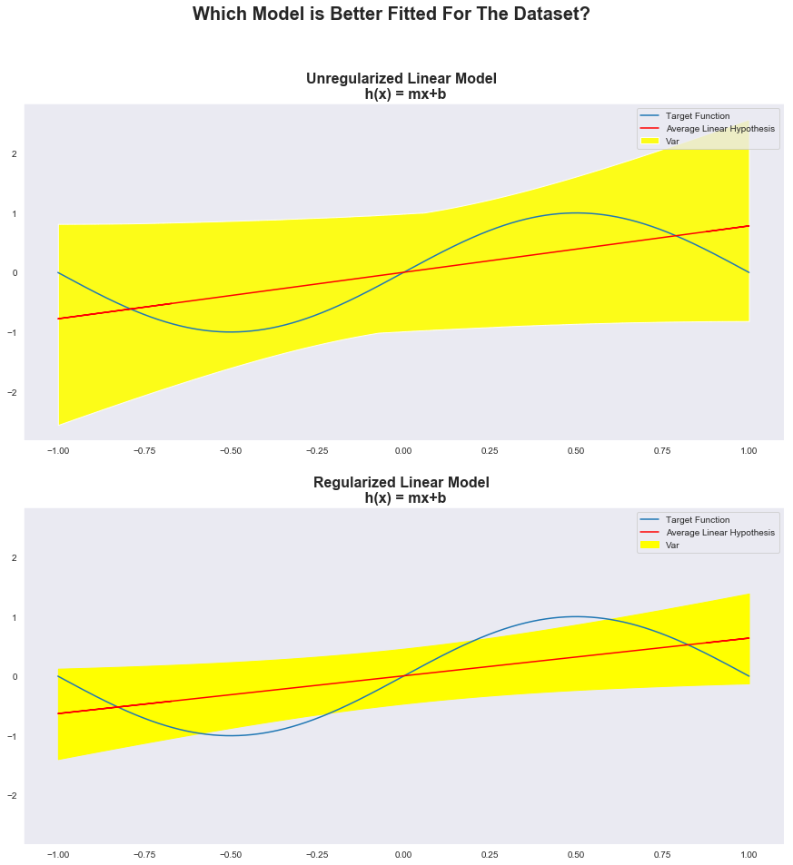

```python
sns.set_style("dark")
sns.set_context({"figure.figsize": (15, 15)})
target_x = np.linspace(-1,1, 10000)
f, ax = plt.subplots(2,sharey=True)
ax[0].plot(target_x, np.sin(np.pi*target_x), label = 'Target Function')
ax[0].plot(point1.T[1], g_bar_un[1]*point1.T[1] + g_bar_un[0], color = 'r', label = 'Average Linear Hypothesis')
ax[0].fill_between(sorted(point1.T[1]) , sorted(unr_upper_limit), sorted(unr_lower_limit), alpha = 0.9, facecolor = 'yellow', label = 'Var')
ax[0].legend()
ax[0].set_title("Unregularized Linear Model \n h(x) = mx+b", fontsize = '16', weight = 'bold')

ax[1].plot(target_x, np.sin(np.pi*target_x), label = 'Target Function')
ax[1].plot(point1.T[1], g_bar_r[1]*point1.T[1] + g_bar_r[0], color = 'r', label = 'Average Linear Hypothesis')
ax[1].set_title("Regularized Linear Model \n h(x) = mx+b", fontsize = '16', weight = 'bold')
ax[1].fill_between(sorted(point1.T[1]), sorted(r_upper_limit), sorted(r_lower_limit), color = 'yellow', label = 'Var')
ax[1].legend()

f.suptitle('Which Model is Better Fitted For The Dataset?', fontsize = '20', weight = 'bold')
plt.show()
```

```python
results = [(round(exp_bias_sq_unr,3), round(exp_bias_sq_r,3)), (round(avg_v_un,3), round(avg_v_r,3))]
index = ["BiasSq", "Var"]
results = DataFrame(results, columns = ["Unregularized", "Regularized"], index=index)
results
```

|  | Unregularized | Regularized |
| --- | --- | --- |
| BiasSq | 0.206 | 0.230 |
| Var | 1.676 | 0.328 |

As we can see the regularized model significantly decreases the variance to the target function at the expense of slightly increasing the squared bias. This makes it the more ideal model to choose.

## Problem 2

Consider the perceptron model in two dimensions with corresponding weights $w0$, $w1$, and $w2$ in figure 1.

1. Determine the equation of the line in $x2 = mx1 + b$ form.
2. Provide a set of values for $w0$, $w1$, and $w2$.
3. Figure 2 shows a perceptron diagram that implements an AND logical operator. Draw a similar diagram for the perceptron model that corresponds to the boundary decision in figure 1.

### 2.1) Determine the Equation of the Line

Looking at the decision boundary we can determine that its slope and y intercept as $m=3$ and $b=1$, thus the line for the decision boundary is $x2=3x1+1$. This is computed simply with the slope formula and seeing where x2 lies when x1 is 0. Any points that lie below this line will be classified as -1 and above will be 1.

### 2.2) Determine the Weights

We know that $m=3$ and that the slope of the decision boundary is equivalent to the following quotient of the weights:

$$m = \frac{-w_{1}}{w_{2}}$$

While the intercept is equivalent to the following:

$$ b = \frac{Threshold}{w_{2}}$$

where the Threshold is equivalent to $-w_{0}$.

Therefore because we have determined the slope and y intercept we can set the equations as follows:

$${3 = \frac{-w_{1}}{w_{2}} \\ 1 = \frac{-w_{0}}{w_{2}}}$$

We can see that the common variable between both is $w_{2}$, therefore we can rewrite both equations in terms of w2:

$$w_{2} = \frac{-w_{1}}{3}$$

$$w_{2} = \frac{-w_{0}}{1}$$

We can then set these equal to each other:

$$w_{2} = \frac{-w_{1}}{3}$$

$$w_{0} = -w_{2}$$

Therefore any value we plug in for $w_{1}$ will give us $w_{2}$ and $w_{0}$

### 2.3) Perceptron Diagram

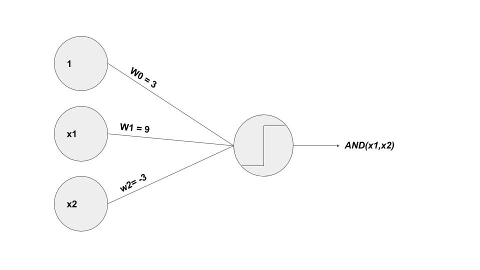

```python
Image(filename = 'perceptron_diagram.png')
```

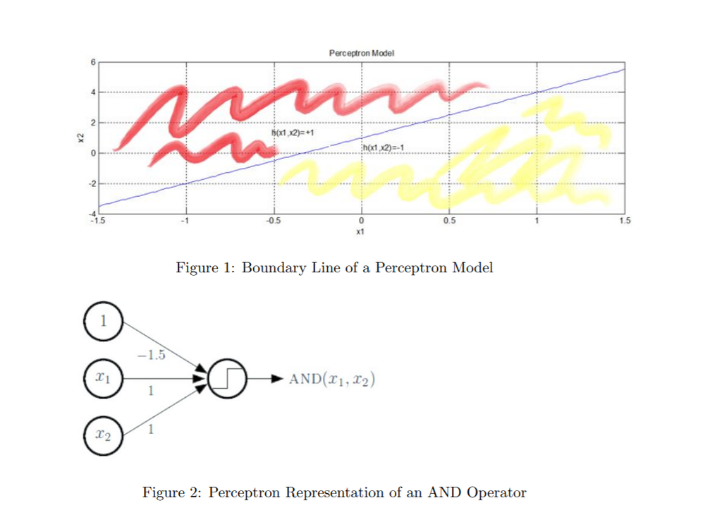

```python
Image(filename = 'chart.png')
```

## Problem 3

An online rental video company is interested in creating a model to make movie recommendations to one of its customers, Ms. X. As a consultant to this company, you are provided with the history of the movies that she accepted or rejected to watch. She makes her selections solely based on the movie genre and critic ratings. The data is in movieData.csv on Canvas.

1. Train a perceptron that will create a linear boundary decision that will help the company to make future recommendations to Ms. X. After how many iterations does the algorithm converge?
2. Upon creating a model, plot the boundary line along with all the data points and axes clearly marked.

```python
movie_df = pd.read_csv('movieData.csv')
```

```python
movie_df
```

|  | Genre | CriticsRating | Watched |
| --- | --- | --- | --- |
| 0 | 1 | 1.2 | -1 |
| 1 | 1 | 3.5 | 1 |
| 2 | 1 | 4.2 | 1 |
| 3 | 2 | 3.9 | 1 |
| 4 | 2 | 2.8 | -1 |
| 5 | 3 | 3.0 | -1 |
| 6 | 5 | 4.5 | -1 |
| 7 | 4 | 1.8 | -1 |
| 8 | 1 | 2.1 | -1 |
| 9 | 3 | 4.8 | 1 |
| 10 | 5 | 4.9 | 1 |
| 11 | 3 | 1.5 | -1 |
| 12 | 3 | 2.6 | -1 |

Because we are using a single neuron for our perceptron, we can simply use the following hypothesis formula to classify whether a movie was watched or not:

$$h(X) = sign(\sum_{i=1}^{d}{w_{i}x_{i}})$$

We will initially choose all random weights for w, and classify the points based on the sign of the resulting dot product between $x$ and $w$. We then update the weights by choosing a mislcassified point $X_{n}$at random and updating the values for $w$ by adding the product of the between $X_{n}$ and its classification $y_{n}$:

$$new\vec{w} = old\vec{w} +y_{n}\vec{X}_{n}$$

Eventually the weights will converge until all points are correctly classified.

### 3.1) Train Perceptron

```python
#Pick random w's
w = np.array([0.9,2,0.5])

#Store each observation in an array with added bias term of 1
X = np.array([np.array([1, movie_df['Genre'].iloc[i] ,movie_df['CriticsRating'].iloc[i]])for i in range(13)])

#Store all y values
y = np.array(movie_df.Watched)


#Compute all sign values with initial random weights
h = np.sign(np.dot(X,w))

#Adjusts w until h converges to y
count = 0
while(np.array_equal(y,h) == False):
    #Get all mislcassified points
    misclass_index = np.where(y!=h)[0]

    #Randomly choose one of the misclassified points
    misclass = random.choice(misclass_index)

    #update w
    oldw = w
    w = oldw + (y[misclass]*X[misclass])
    h = np.sign(np.dot(X,w))
    count = count + 1
print("It took ", count, " iterations to converge")
```

```
It took  96  iterations to converge
```

```python
print("The weights are listed below: \nw0 = ", w[0], '\nw1 = ', w[1], '\nw2 = ', w[2])
```

```
The weights are listed below:
w0 =  -21.1
w1 =  -6.0
w2 =  11.100000000000017
```

### 3.2) Plot the Decision Boundary

```python
t = np.linspace(0,6, 1000)
for val in t:
    slope = -(w[1]/w[2])
    intercept = -w[0]/w[2]
```

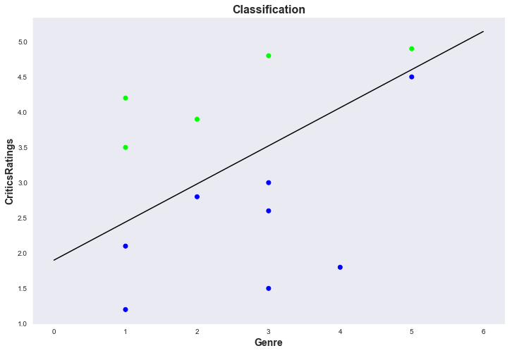

```python
x_range = range(13)
fig, ax = plt.subplots(figsize = (12.0, 8.0))
ax.scatter(movie_df.Genre, movie_df.CriticsRating, c=movie_df.Watched, cmap = 'brg')
ax.plot(t, slope*t + intercept, color='k')
ax.set_xlabel("Genre", weight = "bold", fontsize = 14)
ax.set_ylabel("CriticsRatings", weight = "bold", fontsize = 14)
ax.set_title("Classification", weight = "bold", fontsize = 16)
sns.despine()
t = np.linspace(0,5, 1000)
```

## Problem 4

In this problem you will use the data in siCoData.csv file to train a neural network. Use the backpropagation algorithm to train a 3-layer (input, hidden,output) neural network. Use stochastic gradient decent (SGD) technique and assume that the activation function for the hidden layer and output layer are tanh and linear, respectively. (You must write your own code for BP and SGD).

1. The stopping criteria for training in this problem should be a combination of achieving a minimum in-sample error  
   $E_{in} = \frac{1}{N}\sum_{n=1}^{N} e_{n}$  
   and reaching a maximum number of epochs (In this expression N is the number of observations in the data set and en is the error corresponding to each individual training point). Report the minimum Ein that you could achieve along with the related weights and number of iterations.
2. Graph the original data (y vs. x) and the predicted values ($\hat{y}$ vs. x) on two separate scatter plots.

```python
sicodata = pd.read_csv('siCoData.csv')
sicodata.head(2)
```

|  | x | y |
| --- | --- | --- |
| 0 | -0.889238 | -0.334713 |
| 1 | 0.532539 | 0.898156 |

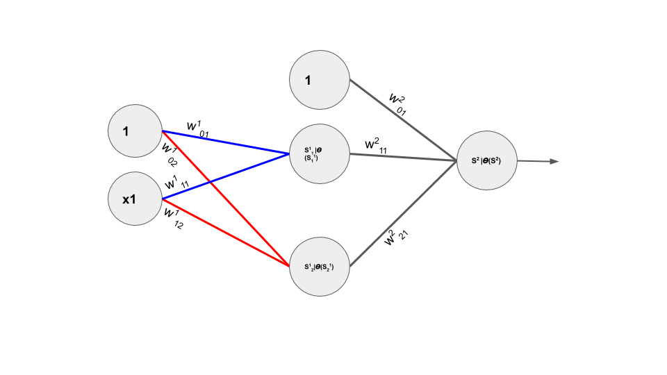

```python
Image(filename = 'neural_net.png')
```

Above is the three layer neural network that we'll be performing back propagation on, where the activation function $\theta (S) = tanh(S_{j})$.

Layer 1 $S_{1}$ is equivalent to the following:

$$S_{1} = \sum_{i=0}^{2} w_{ij}^{1}x_{i}$$

And layer 2 $S_{2}$ equals:

$$S_{2} = \sum_{i=0}^{2} w_{ij}^{2} \theta (S_{i}^{1})$$

We will be using stochastic gradient descent to update the weights as follows:

$$new \vec{w} = old \vec{w} - \eta\nabla en(\vec{w})$$

However, to compute the values of the weights using back propagation, we have to determine the derivatives at every step of the neural network starting from right to left in order to compute the new weights at each layer.

### 4.1) Report In Sample Error, Weights, and Number of Iterations

```python
# Creating X, Y data with column of 1 for bias in X
X = pd.concat([ pd.Series([1]*sicodata.shape[0]), sicodata.iloc[:,0]], 1)
Y = sicodata.iloc[:,1]
```

```python
sicodata.shape
```

```
(250, 2)
```

```python
def dotmul(mat1, mat2):
    """
    Dot product multipication
    """
    return np.dot(mat1,mat2)
```

```python
progress = progressbar.ProgressBar()

"""
Begin Neural Network
"""

# error at every epoch
error_epoch = []

# all errors
error_all = []

# All weights

w1_01_all = []
w1_02_all = []

w1_11_all = []
w1_12_all = []

w2_0_all = []
w2_1_all = []
w2_2_all = []

# initialize weights of layer 1
W1 = np.array([[0.5,0.5],  # W1_01, W1_02
              [0.5,0.3]])  # W1_11, W1_12

# weights of the output layer
W2 =  np.array([0.2,0.5,0.5])


# Predictions using final weights
Yhat = []
count = 0
for epoch_run in progress(range(1000)): # Will never run till 10K

    count = count + 1
    # In same error
    in_sample_error = []


    for i in range(sicodata.shape[0]):

        # First Layer ---------------------

            # Get the Z values of layer 1
        Z1 = np.dot(W1.T,X.values[i].T )

            # Apply activation function of layer 1
        A = np.tanh(Z1)
       # dimensions: 1x1

        A1 = np.append(1,A)

        #Second Layer--------------------

            # Get the Z values of layer 2
        Z2 =  np.dot(W2.T, A1.T)  # Appending the bias to output of layer 1 here

            # Do not apply activation function for the last layer
        A2 = Z2

         #Error--------------------------
        #error1 = nn_error(Y[i],A2)
        error = (A2-Y[i])**2

        #Backpropogation-------------

            # Derive Derivatives

        alpha = 0.005

        # Update weights----------------------

        W1[0][0] = W1[0][0] - (alpha *((2*(A2-Y[i])) * (W2[1]) * (1- (A1[1]**2)) * X.values[i][0])) # First weight of first layer first node
        W1[0][1] = W1[0][1] - (alpha *((2*(A2-Y[i])) * (W2[2]) * (1- (A1[2]**2)) * X.values[i][0])) # second weight of second layer first tnode


        W1[1][0] = W1[1][0] - (alpha *((2*(A2-Y[i])) * (W2[1]) * (1- (A1[1]**2)) * X.values[i][1])) # First weight of first layer second node
        W1[1][1] = W1[1][1] - (alpha *((2*(A2-Y[i])) * (W2[2]) * (1- (A1[2]**2)) * X.values[i][1])) # second weight of second layer second node


        # Update layer 2 weights
        W2[0] = W2[0] - (alpha*((2*(A2-Y[i])) * (A1[0])))  # FIRST weight of second layer
        W2[1] = W2[1] - (alpha*((2*(A2-Y[i])) * (A1[1])))  # Second weight of the second layer
        W2[2] = W2[2] - (alpha*((2*(A2-Y[i])) * (A1[2])))  # third weight of the second layer


        # append every error
        in_sample_error.append(error)


    # append error at the end of each epoch
    error_epoch.append(error)

    # append weights at the end of every epoch
    w1_01_all.append(W1[0][0]), w1_02_all.append(W1[0][1]), w1_11_all.append(W1[1][0]), w1_12_all.append(W1[1][1]), w2_0_all.append(W2[0]), w2_1_all.append(W2[1]), w2_2_all.append(W2[2])

    # Break on mean sample error or if the epoch limit is maximized
    if np.mean(in_sample_error) < 0.02:
        break
```

```
 49% (494 of 1000) |##########           | Elapsed Time: 0:00:47 ETA:   0:00:46
```

[figure not shown]

```python
sns.set_style("darkgrid")
sns.set_context({"figure.figsize": (16, 8)})
f, ax = plt.subplots(1,2)

#Figure 1
ax[0].set_title('Error at Every Epoch', fontsize = 16, weight = "bold")
ax[0].plot(error_epoch)

#Set fonts to consistent 16pt size
for item in ([ax[0].xaxis.label, ax[0].yaxis.label] +
             ax[0].get_xticklabels() + ax[0].get_yticklabels()):
    item.set_fontsize(16)

#Figure 2
ax[1].set_title('All Weights at Each Epoch', fontsize = 16, weight = "bold")
for x,y in zip([w1_01_all, w1_02_all, w1_11_all, w1_12_all,   w2_0_all,    w2_1_all,   w2_2_all ], ['w101', 'w102', 'w111', 'w112','w112', 'w22' ]):
    plt.plot(x, label = '{}'.format(y))

ax[1].legend()



#Set fonts to consistent 16pt size
for item in ([ax[1].xaxis.label, ax[1].yaxis.label] +
             ax[1].get_xticklabels() + ax[1].get_yticklabels()):
    item.set_fontsize(16)
```

```python
# All weights
print("All weights are listed below:")
print("w1_01: ", round(w1_01_all[-1],4))
print("w1_02: ", round(w1_02_all[-1],4))
print("w1_11: ", round(w1_11_all[-1],4))
print("w1_12: ", round(w1_12_all[-1],4))
print("w20: ", round(w2_0_all[-1],4))
print("w21: ", round(w2_1_all[-1],4))
print("w22: ", round(w2_2_all[-1],4))
print("Min in sample error: ", np.min(error_epoch))
print("Number of iterations: ", count)
```

```
All weights are listed below:
w1_01:  -0.0095
w1_02:  -0.0481
w1_11:  2.5413
w1_12:  0.7407
w20:  -0.1421
w21:  2.4383
w22:  -3.3524
Min in sample error:  0.0984243041464713
Number of iterations:  496
```

```python
np.mean(error_epoch)
```

```
0.13410140789502448
```

### 4.2) Plot Original Data vs Predicted Data

```python
# prediction

def preds(X):

    all_preds = []

    for i in range(X.shape[0]):


        W1 = np.array([[w1_01_all[-1],w1_02_all[-1]],
                      [w1_11_all[-1],w1_12_all[-1]]])

#        print (W1)

        W2 = np.array([w2_0_all[-1],w2_1_all[-1], w2_2_all[-1]])

        Z1 = np.dot(W1.T, X.values[i].T)

            # Apply activation function of layer 1
        A = np.tanh(Z1)

        A1 = np.append(1,A)

        #Second Layer--------------------

            # Get the Z values of layer 2
        Z2 =  np.dot(W2, A1.T)  # Appending the bias to output of layer 1 here

            # Do not apply activation function for the last layer
        all_preds.append(Z2)
    return all_preds
```

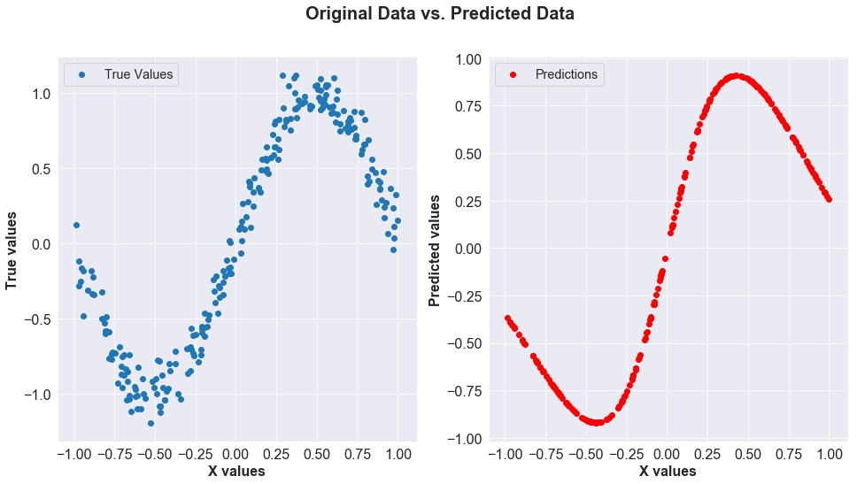

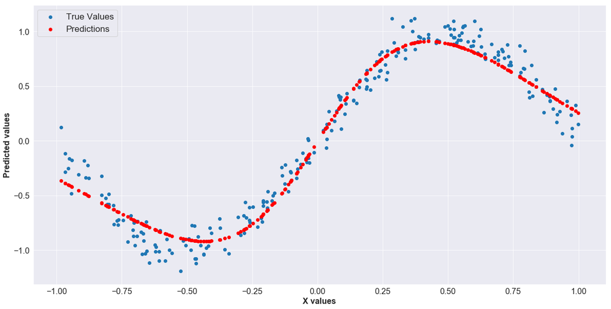

```python
sns.set_style("darkgrid")
sns.set_context({"figure.figsize": (16, 8)})
f, ax = plt.subplots(1,2, sharex=True)
# plotting original data
ax[0].scatter(sicodata.iloc[:,0],sicodata.iloc[:,1] ,label= 'True Values')
ax[0].legend(fontsize = "x-large")
ax[0].set_xlabel('X values', fontsize = 16, weight = "bold")
ax[0].set_ylabel('True values', fontsize = 16, weight = "bold")

#Set fonts to consistent 16pt size
for item in ([ax[0].xaxis.label, ax[0].yaxis.label] +
             ax[0].get_xticklabels() + ax[0].get_yticklabels()):
    item.set_fontsize(16)


ax[1].scatter(sicodata.iloc[:,0],preds(X), c = 'red', label = 'Predictions')
ax[1].legend(fontsize = "x-large")
ax[1].set_xlabel('X values', fontsize = 16, weight = "bold")
ax[1].set_ylabel('Predicted values', fontsize = 16, weight = "bold")

#Set fonts to consistent 16pt size
for item in ([ax[1].xaxis.label, ax[1].yaxis.label] +
             ax[1].get_xticklabels() + ax[1].get_yticklabels()):
    item.set_fontsize(16)

f.suptitle("Original Data vs. Predicted Data", fontsize = 20, weight = "bold")
plt.show()

sns.set_style("darkgrid")
sns.set_context({"figure.figsize": (20, 10)})

f, ax = plt.subplots(1,1)
# plotting predicted data
ax.scatter(sicodata.iloc[:,0],sicodata.iloc[:,1] ,label= 'True Values')
ax.scatter(sicodata.iloc[:,0],preds(X), c = 'red', label = 'Predictions')
ax.legend(fontsize = "xx-large", loc = "upper left")
ax.set_xlabel('X values', fontsize = 18, weight = "bold")
ax.set_ylabel('Predicted values', fontsize = 18, weight = "bold")

for item in ([ax.xaxis.label, ax.yaxis.label] +
             ax.get_xticklabels() + ax.get_yticklabels()):
    item.set_fontsize(16)
plt.show()
```